# Ford GoBike System Presentation

## by (Obichukwu Valentine Nzelu)

## Investigation Overview

> I will focus on the influence of the three critical variables; age, user_type, and member_gender on duration of trips.

> I will start by showing the distribution of duration_min variable, then I will demonstrate how duration varies with member_gender and age

## Dataset Overview

> The dataset includes information about individual rides made in a bike-sharing system covering the greater San Francisco Bay area in February, 2019. The original dataset has 183412 rows and 16 columns; after wrangling, the dataset has 174952 rows and 24 columns. These variables includes the start and end time of the trip, its duration, the start and end station as well as the characterstics of the users such as gender, age and user type (subscriber or customer).

## Distribution of Ride Duration

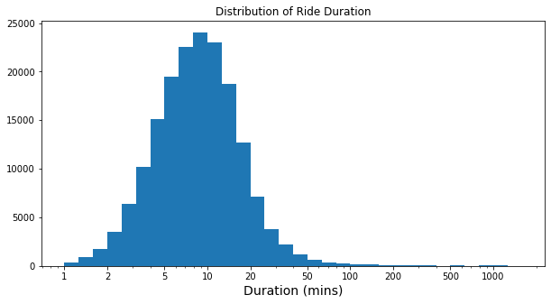

## Duration of Ride by Member Gender and User Type

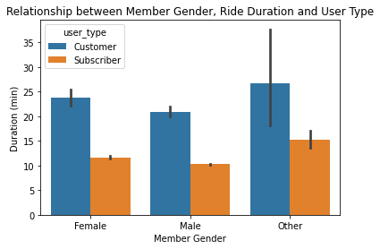

The other gender generally have longer bike trip duration for both the Customer and subscriber user types. We can also observe that the Male gender spend the least time on bike trips for the two user types as well

## Duration of Ride by Age

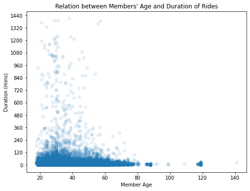

The above visualization shows that the duration of bike rides is lower for older people, while younger people spend more time on bike trips

## Bike Usage by Gender

First we show the daily usage of the bike sharing service on Weekdays and Weekends

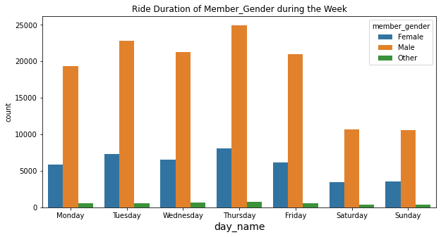

next we show the daily usage of the bike sharing service by start_hour

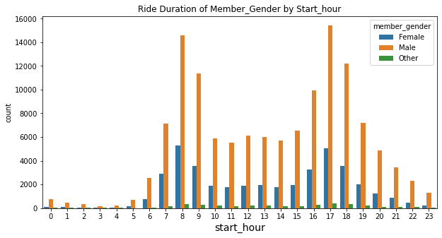

The above visualizations show that:

- There are more male bike users than any other gender type
- The peak period for all bike users (Male,Female and Others) are at 8am and 5pm which happpen to be the resumption and close of works hours

## Conclusions

- The analysis of the dataset tells us that most rides occurs during morning and evening sessions, this could mean that users of the bike-sharing scheme in San Francisco Bay are workers
- There are less female gender participating in the bike-sharing program, so the owners of the program can emply the use of targeted marketing ads to the female and other non gender specific groups
- The bike sharing service should be targeted at younger people as they have longer bike trip durations